# Schizophrenia Real Data Analysis

Ziyi Wang

2026-06-01

## Overview

This document reproduces the Schizophrenia real data analysis using Autoencoder/PCA on metabolic pathway information as side covariates (auxiliary information).

**Key settings (matching the manuscript figure):**

| Parameter | Value |
| --- | --- |
| Dataset | Zhu et al. (Schizophrenia, WGS) |
| Target taxonomic rank | Species |
| Primary test statistic | Wilcoxon z-statistic |
| FDR methods compared | chai, AdaPT-GLM, AdaPT-GMM, OrderShapeEM, FDRreg, IHW, BH |

**Input Autoencoder (AE) and PCA auxiliary file:**

```
chai_project/data/Zhu_autoencoder/outputs/ZhuF_2020_species_AE5.csv
chai_project/data/Zhu_autoencoder/outputs/ZhuF_2020_species_PCA5.csv
```

This file is pre-generated by the autoencoder pipeline (`chai_project/scripts/autoencoder.py`) and is already included in the repository. You do **not** need to re-run the autoencoder pipeline to reproduce these results.

**Working directory:** Knit this file from (`chai_project/scripts/`).

## 1. Install Dependencies

Run once in a fresh R session before knitting:

```r
# CRAN + Bioconductor + GitHub dependencies
source("install_packages.R")

# chai package (not on CRAN)
remotes::install_github("ziyiwang726/chai")
```

## 2. Load Packages

```r
suppressPackageStartupMessages({
  library(curatedMetagenomicData)
  library(SummarizedExperiment)
  library(data.table)
  library(dplyr)
  library(tidyr)
  library(ggplot2)
  library(ggrepel)
  library(GGally)
  library(knitr)
  library(mvtnorm)
  library(mixtools)
  library(KScorrect)
  library(adaptMT)
  library(AdaPTGMM)
  library(splines2)
  library(ggplot2)
  library(coin)
  library(ggrepel)
  library(IHW)
  library(FDRreg)
  library(OrderShapeEM)
  library(chai)
})
```

## 3. Load the data and pre-processing the data

**Note**: The pro-processing part and model fitting chunks could be time-consuming. We saved the processed data together with the organized results after fitting the models. When knitting this HTML file, we loaded the **Schizophrenia_env.RData** file directly and generated the plots from it.

However, for verification or reproducibility, you can also run each pre-processing chunk and/or model-fitting chunk one by one, while skiping the chunk that loads the .RData file. This should produce the same results.

```r
# Load the side information
ae5  <- read.csv("../data/Zhu_autoencoder/outputs/ZhuF_2020_species_AE5.csv", row.names = 1)
pca5 <- read.csv("../data/Zhu_autoencoder/outputs/ZhuF_2020_species_PCA5.csv", row.names = 1)

# generate two random X
set.seed(123)
# Standard normal noise: N(0, 1)
noise <- rnorm(length(z_value))
# Uniform noise on U(0, 1)
noise2 <- runif(length(z_value))

# Helper: extract species label
.extract_species <- function(taxon) {
  sp <- ifelse(grepl("s__", taxon, fixed = TRUE),
               sub(".*s__([^|;]+).*", "\\1", taxon),
               taxon)
  sp <- gsub("^s__", "", sp)
  sp <- gsub("_", " ", sp)
  trimws(sp)
}

# Extract the relative abundance
abun <- curatedMetagenomicData("ZhuF_2020.relative_abundance", dryrun = FALSE)

# Extract the assay matrix
abun_mat <- assay(abun[[1]], "relative_abundance")
# 480 x 171

r_names <- rownames(abun_mat)
taxa_names <- sub("^.*\\|", "", r_names)
species_clean <- .extract_species(taxa_names)
rownames(abun_mat) <- species_clean
# 480 x 171

length(intersect(rownames(ae5), rownames(abun_mat)))
common_species <- intersect(rownames(ae5), rownames(abun_mat))
# 323 sharing

abun_mat_common <- abun_mat[common_species, , drop = FALSE]

# Column-Normalize (column is sample)
cs <- colSums(abun_mat_common, na.rm = TRUE)
cs[cs == 0] <- 1
abun_mat_norm <- sweep(abun_mat_common, 2, cs, FUN = "/")

t_abun <- t(abun_mat_norm)
# 171 subjects x 323 species

######################### outcome ###############################
outcome <- as.factor(abun$`2021-03-31.ZhuF_2020.relative_abundance`[[5]])
# schizophrenia 90 vs. control 81
```

## 4. Wilcoxon Test Statistics

```r
compute_pz_wilcox <- function(t_abun, outcome) {
  stopifnot(nrow(t_abun) == length(outcome))

  p_z_values <- sapply(colnames(t_abun), function(feature) {
    features <- t_abun[, feature, drop = FALSE]
    wilcox <- wilcox_test(features[, 1] ~ outcome)

    c(
      p_value = as.numeric(pvalue(wilcox)),
      z_value = as.numeric(statistic(wilcox))
    )
  }, simplify = "matrix")
  p_z_values <- as.data.frame(t(p_z_values))
  p_z_values$feature <- rownames(p_z_values)
  rownames(p_z_values) <- NULL

  return(p_z_values)
}

p_z_values <- compute_pz_wilcox(t_abun, outcome)

p_value <- p_z_values[,1]
z_value <- p_z_values[,2]
```

## 5. Load the processed data

- **ae5**: the 5-dimensional autoencoder
- **pca5**: the 5-dimensional PCA
- **noise**: the randomly generated noise vector that following a standard normal distribution $~N(0, 1)$
- **noise2**: the randomly generated noise vector that following a uniform distribution $~U(0, 1)$
- **chai_zhu_ae5**: (chai) output with z_value and ae5 as inputs
- **chai_zhu_pca5**: (chai) output with z_value and pca5 as inputs
- **chai_zhu_noise**: (chai) output with z_value and noise as inputs
- **chai_zhu_noise2**: (chai) output with z_value and noise2 as inputs
- **zhu_ae**: the summary table saving the number of selections of every method at different q, with ae5 as side information.
- **zhu_ae_long**: the long table version of zhu_ae for plot purpose.
- **zhu_ae_pca**: the summary table saving the number of selections of every method at different q, with different side information (included ae5, pca5, noise, and noise2).
- **zhu_ae_pca_long**: the long table version of zhu_ae_pca for plot purpose.

```r
load("../data/chai_env/Schizophrenia_env.RData")
```

## 6. Multiple Testing Methods

### 6a. BH Fit the models

```r
q_levels <- seq(0.01, 0.1, by = 0.01)

p_adjusted <- p.adjust(p_value, method = "BH")
bh_rejs <- sapply(q_levels, function(q) {
  length(which(p_adjusted <= q))
})
```

### 6b. chai

```r
set.seed(123)
chai_zhu_ae5 <- chai(z_value, ae5, B = 100)       # autoencoder
chai_rejs_ae5 <- sapply(q_levels, function(q) {
  length(clfdrselect(chai_zhu_ae5$clFDR, q, 1))
})

chai_zhu_pca5 <- chai(z_value, pca5, B = 100)     # pca
chai_rejs_pca5 <- sapply(q_levels, function(q) {
  length(clfdrselect(chai_zhu_pca5$clFDR, q, 1))
})

chai_zhu_noise <- chai(z_value, noise, B = 100)   # noise 1 (~N(0, 1))
chai_rejs_noise <- sapply(q_levels, function(q) {
  length(clfdrselect(chai_zhu_noise$clFDR, q, 1))
})

chai_zhu_noise2 <- chai(z_value, noise2, B = 100) # noise 2 (~U(0, 1))
chai_rejs_noise2 <- sapply(q_levels, function(q) {
  length(clfdrselect(chai_zhu_noise2$clFDR, q, 1))
})
```

### 6c. AdaPT-GLM

```r
# autoencoder
x_ae5 <- data.frame(ae5)
make_ns_formulas <- function(dfs) {
  lapply(dfs, function(d)
    as.formula(paste0("~ ns(AE1, df=", d, ") + ns(AE2, df=", d, ") + ns(AE3, df=", d, ") +
                      ns(AE4, df=", d, ") + ns(AE5, df=", d, ")"))
  )
}
dfs <- c(2, 4, 6, 8)
formula_ns_ae5 <- make_ns_formulas(dfs)

glm_ns_ae5 <- adapt_glm(x_ae5, pvals = p_value, alphas=q_levels,
                        pi_formulas = formula_ns_ae5, mu_formulas = formula_ns_ae5)
adapt_glm_ns_ae5 <- glm_ns_ae5$nrejs

# pca
x_pca5 <- data.frame(pca5)
make_ns_formulas <- function(dfs) {
  lapply(dfs, function(d)
    as.formula(paste0("~ ns(PC1, df=", d, ") + ns(PC2, df=", d, ") + ns(PC3, df=", d, ") +
                      ns(PC4, df=", d, ") + ns(PC5, df=", d, ")"))
  )
}
dfs <- c(2, 4, 6, 8)
formula_ns_pca5 <- make_ns_formulas(dfs)

glm_ns_pca5 <- adapt_glm(x_pca5, pvals = p_value, alphas=q_levels,
                         pi_formulas = formula_ns_pca5, mu_formulas = formula_ns_pca5)
adapt_glm_ns_pca5 <- glm_ns_pca5$nrejs

# noise
x_noise <- data.frame(noise)
formula_ns_noise <- paste0("ns(noise, df = ", 2:8, ")")

glm_ns_noise <- adapt_glm(x_noise, pvals = p_value, alphas=q_levels,
                          pi_formulas = formula_ns_noise, mu_formulas = formula_ns_noise)
adapt_glm_ns_noise <- glm_ns_noise$nrejs

# noise2
x_noise2 <- data.frame(noise2)
formula_ns_noise2 <- paste0("ns(noise2, df = ", 2:8, ")")

glm_ns_noise2 <- adapt_glm(x_noise2, pvals = p_value, alphas=q_levels,
                           pi_formulas = formula_ns_noise2, mu_formulas = formula_ns_noise2)
adapt_glm_ns_noise2 <- glm_ns_noise2$nrejs
```

### 6d. AdaPT-GMM (p-values)

```r
# autoencoder
gmm_ns_p_ae5 <- adapt_gmm(x_ae5, pvals = p_value,  alphas=q_levels,
                          beta_formulas = formula_ns_ae5)
adapt_gmm_p_ns_ae5 <- gmm_ns_p_ae5$nrejs

# pca
gmm_ns_p_pca5 <- adapt_gmm(x_pca5, pvals = p_value,  alphas=q_levels,
                           beta_formulas = formula_ns_pca5)
adapt_gmm_p_ns_pca5 <- gmm_ns_p_pca5$nrejs

# noise
gmm_ns_p_noise <- adapt_gmm(x_noise, pvals = p_value,  alphas=q_levels,
                            beta_formulas = formula_ns_noise)
adapt_gmm_p_ns_noise <- gmm_ns_p_noise$nrejs

# noise2
gmm_ns_p_noise2 <- adapt_gmm(x_noise2, pvals = p_value,  alphas=q_levels,
                             beta_formulas = formula_ns_noise2)
adapt_gmm_p_ns_noise2 <- gmm_ns_p_noise2$nrejs
```

### 6e. AdaPT-GMM (z-statistics)

```r
# autoencoder
gmm_ns_z_ae5 <- adapt_gmm(x_ae5, z = z_value, alphas=q_levels,
                          beta_formulas = formula_ns_ae5, testing = "two_sided")
adapt_gmm_z_ns_ae5 <- gmm_ns_z_ae5$nrejs

# pca
gmm_ns_z_pca5 <- adapt_gmm(x_pca5, z = z_value, alphas=q_levels,
                           beta_formulas = formula_ns_pca5, testing = "two_sided")
adapt_gmm_z_ns_pca5 <- gmm_ns_z_pca5$nrejs


# noise
gmm_ns_z_noise <- adapt_gmm(x_noise, z = z_value,  alphas=q_levels,
                            beta_formulas = formula_ns_noise, testing = "two_sided")
adapt_gmm_z_ns_noise <- gmm_ns_z_noise$nrejs

# noise2
gmm_ns_z_noise2 <- adapt_gmm(x_noise2, z = z_value,  alphas=q_levels,
                             beta_formulas = formula_ns_noise2, testing = "two_sided")
adapt_gmm_z_ns_noise2 <- gmm_ns_z_noise2$nrejs
```

### 6f. OrderShapeEM

```r
# Define a function that can fit the easily fit every column of side information into OrderShapeEM
run_ordershape_by_col <- function(mat, dataset = c("ae5", "pca5")) {
  dataset <- match.arg(dataset)

  res <- vector("list", ncol(mat))
  names(res) <- paste0("ordershape_x", seq_len(ncol(mat)), "_", dataset)

  for (j in seq_len(ncol(mat))) {
    message("Fitting OrderShapeEM for column ", j)
    res[[j]] <- OrderShapeEM(
      pvals     = p_value,
      order.var = mat[, j],
      OrderShapeEM.control(trace = TRUE)
    )
  }
  res
}

# Define a function to count how many selections that OrderShapeEM made at each q level
count_ordershape_selections <- function(os_list, q_levels) {
  # os_list: list like ordershape_ae5 or ordershape_pca5
  # returns a matrix: rows = q_levels, cols = each x1/x2/...
  res <- sapply(os_list, function(os) {
    # for one ordershape object
    sapply(q_levels, function(q) sum(os$fdr <= q))
  })
  # sapply gives q_levels in rows; make that explicit:
  rownames(res) <- paste0("q=", q_levels)
  res
}

# autoencoder
ordershape_ae5 <- run_ordershape_by_col(ae5, dataset = "ae5")
ordershape_ae5  <- count_ordershape_selections(ordershape_ae5,  q_levels)

# pca
ordershape_pca5 <- run_ordershape_by_col(pca5, dataset = "pca5")
ordershape_pca5 <- count_ordershape_selections(ordershape_pca5, q_levels)

# noise
ordershape_noise <- OrderShapeEM(pvals = p_value, order.var = noise,
                                 OrderShapeEM.control(trace = TRUE))
ordershapeem_noise <- sapply(q_levels, function(q) {
  sum(ordershape_noise$fdr <= q)
})

# noise2
ordershape_noise2 <- OrderShapeEM(pvals = p_value, order.var = noise2,
                                  OrderShapeEM.control(trace = TRUE))
ordershapeem_noise2 <- sapply(q_levels, function(q) {
  sum(ordershape_noise2$fdr <= q)
})
```

### 6g. FDRreg

```r
set.seed(123)
fdr_theo_ae5 <- FDRreg(z_value, as.matrix(ae5), nulltype = 'theoretical')
rdrreg_ae5 <- sapply(q_levels, function(q) {
  length(which(fdr_theo_ae5$FDR <= q))
})

fdr_theo_pca5 <- FDRreg(z_value, as.matrix(pca5), nulltype = 'theoretical')
rdrreg_pca5 <- sapply(q_levels, function(q) {
  length(which(fdr_theo_pca5$FDR <= q))
})

fdr_theo_noise <- FDRreg(z_value, as.matrix(noise), nulltype = 'theoretical')
rdrreg_noise <- sapply(q_levels, function(q) {
  length(which(fdr_theo_noise$FDR <= q))
})

fdr_theo_noise2 <- FDRreg(z_value, as.matrix(noise2), nulltype = 'theoretical')
rdrreg_noise2 <- sapply(q_levels, function(q) {
  length(which(fdr_theo_noise2$FDR <= q))
})
```

### 6h. IHW

** Note: ** Careful on running IHW.

```r
# Careful on IHW!!!!! May cause R terminated.
# autoencoder
ihw_x1_ae5 <- sapply(q_levels, function(q) {
  ihw <- ihw(pvalues = p_value, covariates = ae5[,1], alpha = q, nbins = 5)
  rejections(ihw)
})

ihw_x2_ae5 <- sapply(q_levels, function(q) {
  ihw <- ihw(pvalues = p_value, covariates = ae5[,2], alpha = q, nbins = 5)
  rejections(ihw)
})

ihw_x3_ae5 <- sapply(q_levels, function(q) {
  ihw <- ihw(pvalues = p_value, covariates = ae5[,3], alpha = q, nbins = 5)
  rejections(ihw)
})

ihw_x4_ae5 <- sapply(q_levels, function(q) {
  ihw <- ihw(pvalues = p_value, covariates = ae5[,4], alpha = q, nbins = 5)
  rejections(ihw)
})

ihw_x5_ae5 <- sapply(q_levels, function(q) {
  ihw <- ihw(pvalues = p_value, covariates = ae5[,5], alpha = q, nbins = 5)
  rejections(ihw)
})

# pca
ihw_x1_pca5 <- sapply(q_levels, function(q) {
  ihw <- ihw(pvalues = p_value, covariates = pca5[,1], alpha = q, nbins = 5)
  rejections(ihw)
})

ihw_x2_pca5 <- sapply(q_levels, function(q) {
  ihw <- ihw(pvalues = p_value, covariates = pca5[,2], alpha = q, nbins = 5)
  rejections(ihw)
})

ihw_x3_pca5 <- sapply(q_levels, function(q) {
  ihw <- ihw(pvalues = p_value, covariates = pca5[,3], alpha = q, nbins = 5)
  rejections(ihw)
})

ihw_x4_pca5 <- sapply(q_levels, function(q) {
  ihw <- ihw(pvalues = p_value, covariates = pca5[,4], alpha = q, nbins = 5)
  rejections(ihw)
})

ihw_x5_pca5 <- sapply(q_levels, function(q) {
  ihw <- ihw(pvalues = p_value, covariates = pca5[,5], alpha = q, nbins = 5)
  rejections(ihw)
})

# noise
ihw_noise <- sapply(q_levels, function(q) {
  ihw <- ihw(pvalues = p_value, covariates = noise, alpha = q, nbins = 5)
  rejections(ihw)
})

# noise2
ihw_noise2 <- sapply(q_levels, function(q) {
  ihw <- ihw(pvalues = p_value, covariates = noise2, alpha = q, nbins = 5)
  rejections(ihw)
})
```

## 7. Main Figure

```r
############################# AE results only ###########################
# combine results into data frame
zhu_ae <- data.frame(
  q = q_levels,
  chai = chai_rejs_ae5,
  adapt_glm = adapt_glm_ns_ae5,
  adapt_gmm_p = adapt_gmm_p_ns_ae5,
  adapt_gmm_z = adapt_gmm_z_ns_ae5,
  OrderShapeEM_x1 = ordershape_ae5[, 1],
  OrderShapeEM_x2 = ordershape_ae5[, 2],
  OrderShapeEM_x3 = ordershape_ae5[, 3],
  OrderShapeEM_x4 = ordershape_ae5[, 4],
  OrderShapeEM_x5 = ordershape_ae5[, 5],
  FDRreg = rdrreg_ae5,
  IHW_x1 = ihw_x1_ae5,
  IHW_x2 = ihw_x2_ae5,
  IHW_x3 = ihw_x3_ae5,
  IHW_x4 = ihw_x4_ae5,
  IHW_x5 = ihw_x5_ae5,
  BH = bh_rejs
)

# Converge into long table for plot purpose
zhu_ae_long <- zhu_ae %>%
  pivot_longer(
    cols = -q,
    names_to = "Method",
    values_to = "Rejections"
  ) %>%
  mutate(Method = as.character(Method))

############################# AE and PCA results ###########################
zhu_ae_pca <- data.frame(
  q = q_levels,
  chai_ae = chai_rejs_ae5,
  chai_pca = chai_rejs_pca5,
  chai_noise1 = chai_rejs_noise,
  chai_noise2 = chai_rejs_noise2,
  adapt_glm_ae = adapt_glm_ns_ae5,
  adapt_glm_pca = adapt_glm_ns_pca5,
  adapt_glm_noise1 = adapt_glm_ns_noise,
  adapt_glm_noise2 = adapt_glm_ns_noise2,
  adapt_gmm_p_ae = adapt_gmm_p_ns_ae5,
  adapt_gmm_p_pca = adapt_gmm_p_ns_pca5,
  adapt_gmm_p_noise1 = adapt_gmm_p_ns_noise,
  adapt_gmm_p_noise2 = adapt_gmm_p_ns_noise2,
  adapt_gmm_z_ae = adapt_gmm_z_ns_ae5,
  adapt_gmm_z_pca = adapt_gmm_z_ns_pca5,
  adapt_gmm_z_noise1 = adapt_gmm_z_ns_noise,
  adapt_gmm_z_noise2 = adapt_gmm_z_ns_noise2,
  fdrreg_ae = rdrreg_ae5,
  fdrreg_pca = rdrreg_pca5,
  fdrreg_noise1 = rdrreg_noise,
  fdrreg_noise2 = rdrreg_noise2,
  bh = bh_rejs
)

# Converge into long table for plot purpose
zhu_ae_pca_long <- zhu_ae_pca %>%
  pivot_longer(
    cols = -q,
    names_to  = "name",
    values_to = "Rejections"
  ) %>%
  mutate(
    side = case_when(
      grepl("_ae$",   name) ~ "ae",
      grepl("_pca$",  name) ~ "pca",
      grepl("_noise1$", name) ~ "noise1",
      grepl("_noise2$", name) ~ "noise2",
      TRUE                    ~ "bh"        # BH has no suffix
    ),
    Method = case_when(
      side == "bh" ~ "bh",
      TRUE         ~ sub("_(ae|pca|noise1|noise2)$", "", name)
    )
  )
```

### 7a. Number of Discoveries vs FDR Threshold

Line chart of number or selections by every method at different FDR q level.

```r
source("consistant_color.R")
p_zhu_ae <- plot_rejections_vs_q(zhu_ae_long,
                                 x_breaks = sort(unique(zhu_ae_long$q)))
```

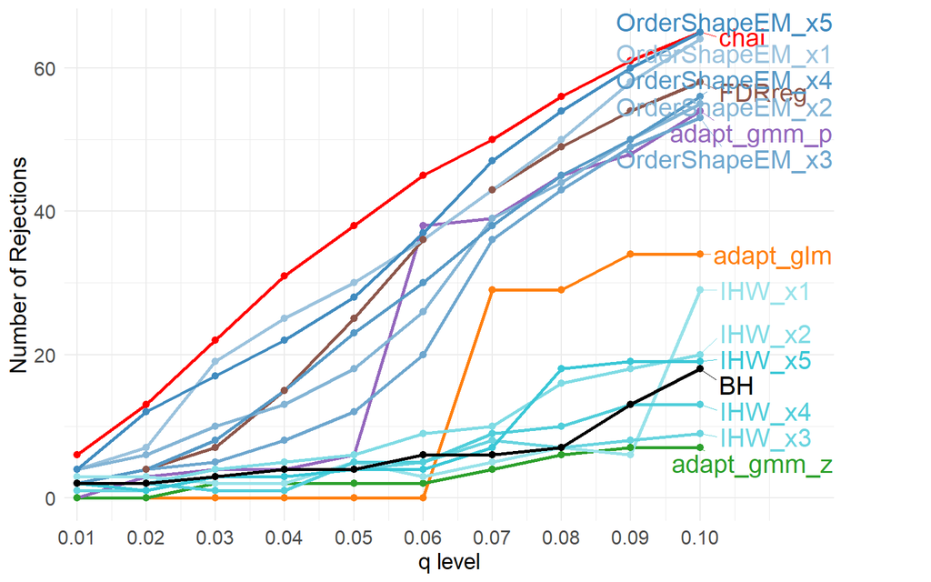

```r
p_zhu_ae
```

```r
zhu_ae_pca_long$side <- factor(zhu_ae_pca_long$side, levels = c("ae", "pca", "noise1", "noise2"))

# Only methods with the three side-info types (drop BH panel)
zhu_long_methods <- zhu_ae_pca_long %>%
  filter(side != "bh", Method != "bh")

# --- Put 'chai' as the first facet ----------------------------------------
method_levels <- c("chai", setdiff(unique(as.character(zhu_long_methods$Method)), "chai"))

zhu_long_methods <- zhu_long_methods %>%
  mutate(Method = factor(Method, levels = method_levels))

# --- End-of-line label positions (one per Method C side) -------------------
endpoints <- zhu_long_methods %>%
  arrange(Method, side, q) %>%
  group_by(Method, side) %>%
  slice_tail(n = 1) %>%
  ungroup()

dx <- diff(range(zhu_long_methods$q))

# BH baseline (as before)
bh_line <- zhu_ae_pca_long %>%
  dplyr::filter(Method == "bh") %>%
  dplyr::select(q, Rejections) %>%
  tidyr::crossing(Method = method_levels) %>%
  # IMPORTANT: make Method a factor with same levels
  mutate(Method = factor(Method, levels = method_levels))

# Endpoints for BH (one per Method)
bh_endpoints <- bh_line %>%
  group_by(Method) %>%
  slice_max(q, with_ties = FALSE) %>%
  ungroup()

p_ae_pca <- ggplot(zhu_long_methods,
                   aes(x = q, y = Rejections, color = side)) +
  geom_line(linewidth = 1) +
  geom_point(size = 2) +
  geom_text_repel(
    data = endpoints,
    aes(label = side),
    nudge_x      = dx * 0.03,
    hjust        = 0,
    direction    = "y",
    segment.size = 0.2,
    box.padding  = 0.1,
    point.padding= 0.1,
    show.legend  = FALSE
  ) +
  # BH dashed line
  geom_line(
    data        = bh_line,
    aes(x = q, y = Rejections, group = 1),
    inherit.aes = FALSE,
    color       = "black",
    linewidth   = 0.8,
    linetype    = "dashed"
  ) +
  # "bh" label
  geom_text(
    data        = bh_endpoints,
    aes(x = q, y = Rejections, label = "bh"),
    inherit.aes = FALSE,
    nudge_x     = dx * 0.03,
    hjust       = 0,
    vjust       = 0.5,
    size        = 3,
    color       = "black"
  ) +
  facet_wrap(~ Method) +  # <-- remove scales = "free_y"
  scale_x_continuous(breaks = unique(zhu_long_methods$q)) +
  scale_y_continuous(limits = c(0, max(zhu_long_methods$Rejections))) +
  scale_color_manual(
    values = c(
      ae    = "red",
      pca   = "blue",
      noise1 = "grey50",
      noise2 = "grey70"
    )
  ) +
  labs(
    # title  = "Number of Discoveries at different q level",
    x      = "q level",
    y      = "Number of Rejections",
    color  = "Side information: "
  ) +
  coord_cartesian(clip = "off") +
  expand_limits(x = max(zhu_long_methods$q) + dx * 0.05) +
  theme_minimal() +
  theme(
    strip.text      = element_text(face = "bold"),
    legend.position = "bottom",
    plot.margin     = margin(5.5, 60, 5.5, 5.5)
  )
```

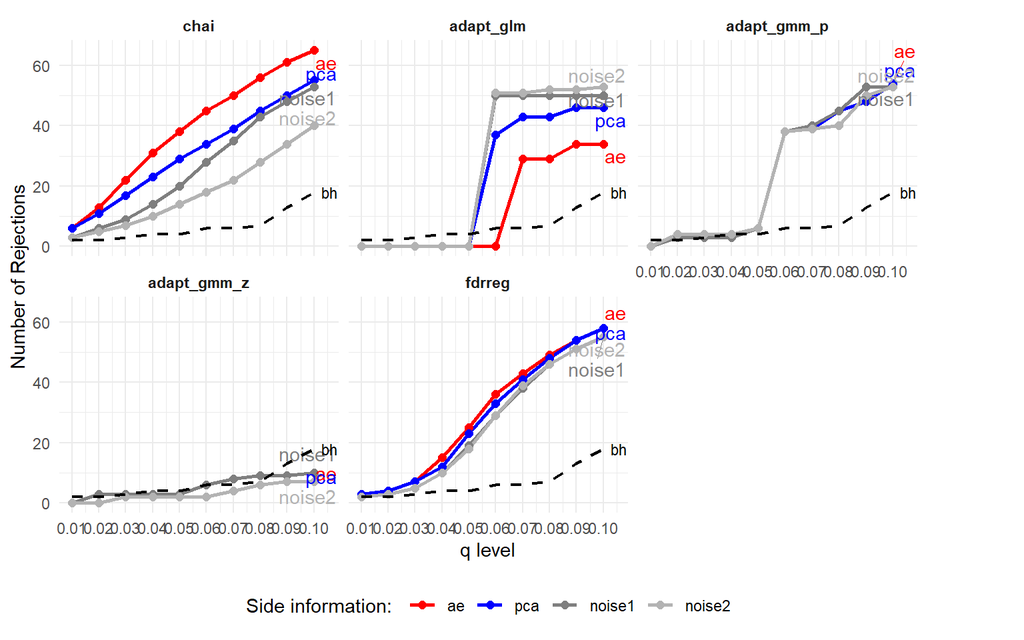

```r
p_ae_pca
```